# 2do Proyecto: Predicción de precios de viviendas

Buenas, este es mi segundo proyecto de Kaggle, en esta ocación voy a predecir los precios de las casas mediante una regresión. Para empezar se importaran los paquetes necesarios:

```python
#--------------------------------------------------------- Los paquetes necesarios -----------------------------------------------------------
# El paquete para control y manejo del conjunto de datos
import pandas as pd
pd.set_option('display.max_columns',None)
pd.set_option('display.max_rows',None)

# El paquete para el control de elementos matemáticas, estadísticos y arreglos/matrices/vectores
import numpy as np

# Los paquetes de visualización necesarios
import matplotlib.pyplot as plt
import seaborn as sns
from matplotlib import rcParams

# Preprocesamiento de datos
from sklearn.preprocessing import LabelEncoder, StandardScaler, RobustScaler, PowerTransformer
from sklearn.experimental import enable_iterative_imputer
from sklearn.impute import KNNImputer, SimpleImputer, IterativeImputer
from sklearn.neighbors import KNeighborsClassifier
from sklearn.model_selection import train_test_split
from sklearn.ensemble import RandomForestClassifier, RandomForestRegressor
import scipy.stats as stats
import statsmodels.api as sm

# Aplicando una configuración de visualizacion por defecto con Seaborn
sns.set_style()
sns.set(rc={'figure.figsize':(13,8)})
```

Una vez importadas las herramientas, procedo a importar los datos descargados de Kaggle:

```python
# Los datos de entrenamiento
datos_entrenamiento = pd.read_csv('house-prices-advanced-regression-techniques/train.csv')

# Los datos de prueba
datos_prueba = pd.read_csv('house-prices-advanced-regression-techniques/test.csv')
```

## Análisis exploratorio de los datos (EDA)

Importado los datos, procedo a revisarlos:

```python
datos_entrenamiento.head()
```

|  | Id | MSSubClass | MSZoning | LotFrontage | LotArea | Street | Alley | LotShape | LandContour | Utilities | LotConfig | LandSlope | Neighborhood | Condition1 | Condition2 | BldgType | HouseStyle | OverallQual | OverallCond | YearBuilt | YearRemodAdd | RoofStyle | RoofMatl | Exterior1st | Exterior2nd | MasVnrType | MasVnrArea | ExterQual | ExterCond | … |
| --- | --- | --- | --- | --- | --- | --- | --- | --- | --- | --- | --- | --- | --- | --- | --- | --- | --- | --- | --- | --- | --- | --- | --- | --- | --- | --- | --- | --- | --- | --- |
| 0 | 1 | 60 | RL | 65.0 | 8450 | Pave | NaN | Reg | Lvl | AllPub | Inside | Gtl | CollgCr | Norm | Norm | 1Fam | 2Story | 7 | 5 | 2003 | 2003 | Gable | CompShg | VinylSd | VinylSd | BrkFace | 196.0 | Gd | TA | … |
| 1 | 2 | 20 | RL | 80.0 | 9600 | Pave | NaN | Reg | Lvl | AllPub | FR2 | Gtl | Veenker | Feedr | Norm | 1Fam | 1Story | 6 | 8 | 1976 | 1976 | Gable | CompShg | MetalSd | MetalSd | None | 0.0 | TA | TA | … |
| 2 | 3 | 60 | RL | 68.0 | 11250 | Pave | NaN | IR1 | Lvl | AllPub | Inside | Gtl | CollgCr | Norm | Norm | 1Fam | 2Story | 7 | 5 | 2001 | 2002 | Gable | CompShg | VinylSd | VinylSd | BrkFace | 162.0 | Gd | TA | … |
| 3 | 4 | 70 | RL | 60.0 | 9550 | Pave | NaN | IR1 | Lvl | AllPub | Corner | Gtl | Crawfor | Norm | Norm | 1Fam | 2Story | 7 | 5 | 1915 | 1970 | Gable | CompShg | Wd Sdng | Wd Shng | None | 0.0 | TA | TA | … |
| 4 | 5 | 60 | RL | 84.0 | 14260 | Pave | NaN | IR1 | Lvl | AllPub | FR2 | Gtl | NoRidge | Norm | Norm | 1Fam | 2Story | 8 | 5 | 2000 | 2000 | Gable | CompShg | VinylSd | VinylSd | BrkFace | 350.0 | Gd | TA | … |

```python
datos_entrenamiento.shape
```

```
(1460, 81)
```

```python
datos_prueba.head()
```

|  | Id | MSSubClass | MSZoning | LotFrontage | LotArea | Street | Alley | LotShape | LandContour | Utilities | LotConfig | LandSlope | Neighborhood | Condition1 | Condition2 | BldgType | HouseStyle | OverallQual | OverallCond | YearBuilt | YearRemodAdd | RoofStyle | RoofMatl | Exterior1st | Exterior2nd | MasVnrType | MasVnrArea | ExterQual | ExterCond | … |
| --- | --- | --- | --- | --- | --- | --- | --- | --- | --- | --- | --- | --- | --- | --- | --- | --- | --- | --- | --- | --- | --- | --- | --- | --- | --- | --- | --- | --- | --- | --- |
| 0 | 1461 | 20 | RH | 80.0 | 11622 | Pave | NaN | Reg | Lvl | AllPub | Inside | Gtl | NAmes | Feedr | Norm | 1Fam | 1Story | 5 | 6 | 1961 | 1961 | Gable | CompShg | VinylSd | VinylSd | None | 0.0 | TA | TA | … |
| 1 | 1462 | 20 | RL | 81.0 | 14267 | Pave | NaN | IR1 | Lvl | AllPub | Corner | Gtl | NAmes | Norm | Norm | 1Fam | 1Story | 6 | 6 | 1958 | 1958 | Hip | CompShg | Wd Sdng | Wd Sdng | BrkFace | 108.0 | TA | TA | … |
| 2 | 1463 | 60 | RL | 74.0 | 13830 | Pave | NaN | IR1 | Lvl | AllPub | Inside | Gtl | Gilbert | Norm | Norm | 1Fam | 2Story | 5 | 5 | 1997 | 1998 | Gable | CompShg | VinylSd | VinylSd | None | 0.0 | TA | TA | … |
| 3 | 1464 | 60 | RL | 78.0 | 9978 | Pave | NaN | IR1 | Lvl | AllPub | Inside | Gtl | Gilbert | Norm | Norm | 1Fam | 2Story | 6 | 6 | 1998 | 1998 | Gable | CompShg | VinylSd | VinylSd | BrkFace | 20.0 | TA | TA | … |
| 4 | 1465 | 120 | RL | 43.0 | 5005 | Pave | NaN | IR1 | HLS | AllPub | Inside | Gtl | StoneBr | Norm | Norm | TwnhsE | 1Story | 8 | 5 | 1992 | 1992 | Gable | CompShg | HdBoard | HdBoard | None | 0.0 | Gd | TA | … |

```python
datos_prueba.shape
```

```
(1459, 80)
```

En primera instancia, se puede ver que los conjuntos de prueba y entrenamiento se componen de 1459 y 1460 casa cada uno respectivamente, además que el conjunto de datos en general tiene **81 variables**. En el conjunto de pruebas se ve que hay una variable menos, debido a que precisamente es la variable a predecir. Revisando más a fondo se tiene lo siguiente:

```python
datos_entrenamiento.info()
```

```
<class 'pandas.core.frame.DataFrame'>
RangeIndex: 1460 entries, 0 to 1459
Data columns (total 81 columns):
 #   Column         Non-Null Count  Dtype
---  ------         --------------  -----
 0   Id             1460 non-null   int64
 1   MSSubClass     1460 non-null   int64
 2   MSZoning       1460 non-null   object
 3   LotFrontage    1201 non-null   float64
 4   LotArea        1460 non-null   int64
 5   Street         1460 non-null   object
 6   Alley          91 non-null     object
 7   LotShape       1460 non-null   object
 8   LandContour    1460 non-null   object
 9   Utilities      1460 non-null   object
```

[output cut: 73 more lines]

Se ve que el conjunto de entrenamiento contiene **38 variables numéricas y 43 del tipo objeto, es decir, categóricas**. Por otro lado se ve una cantidad considerable de valores nulos, y estas se concentran por lo visto en variables categóricas. Ahora por otro lado, en el conjunto de prueba se tiene:

```python
datos_prueba.info()
```

```
<class 'pandas.core.frame.DataFrame'>
RangeIndex: 1459 entries, 0 to 1458
Data columns (total 80 columns):
 #   Column         Non-Null Count  Dtype
---  ------         --------------  -----
 0   Id             1459 non-null   int64
 1   MSSubClass     1459 non-null   int64
 2   MSZoning       1455 non-null   object
 3   LotFrontage    1232 non-null   float64
 4   LotArea        1459 non-null   int64
 5   Street         1459 non-null   object
 6   Alley          107 non-null    object
 7   LotShape       1459 non-null   object
 8   LandContour    1459 non-null   object
 9   Utilities      1457 non-null   object
```

[output cut: 72 more lines]

Se ve que por la falta de la variable a predecir, este se compone de **37 variables numéricas y 43 categóricas**. Algo importante a ver es que el conjunto de pruebas tiene un mayor número de variables decimales que en el conjunto de entrenamiento. Al igual que en el otro conjunto, este también tiene un número considerable de valores faltante.

## Tratando los valores faltantes (NaN)

Lo primero a tratar antes de seguir cualquier análisis estadístico de los datos son los NaN o valores faltantes. Para ello procedo a revisar la cantidad de NaN que presentan los datos:

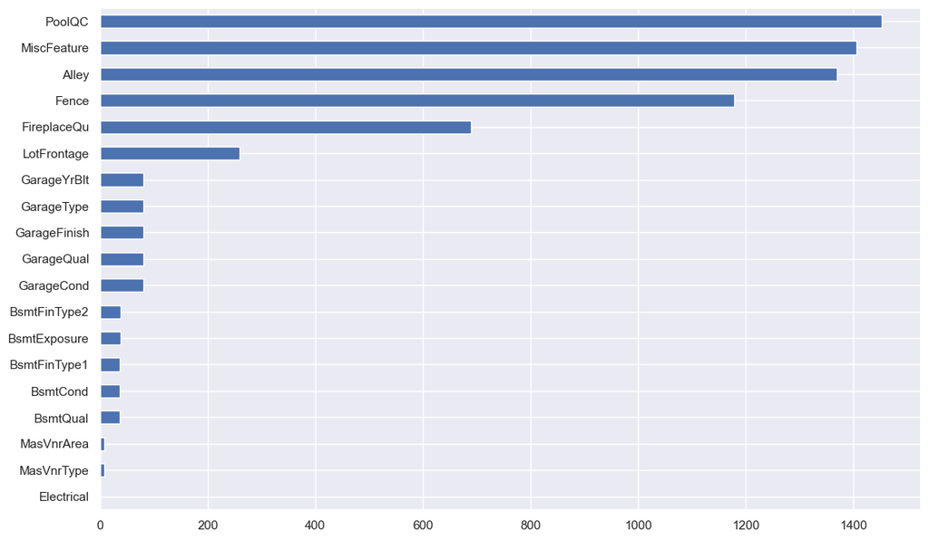

```python
datos_nulos_entrenamiento = datos_entrenamiento.isnull().sum()[datos_entrenamiento.isnull().sum() > 0]
datos_nulos_entrenamiento.sort_values().plot.barh();
```

```python
print('El número de NaN en los datos de entrenamiento:')
print(datos_nulos_entrenamiento.sort_values(ascending = False))
print('El total de NaN:',datos_nulos_entrenamiento.sum())
```

```
El número de NaN en los datos de entrenamiento:
PoolQC          1453
MiscFeature     1406
Alley           1369
Fence           1179
FireplaceQu      690
LotFrontage      259
GarageType        81
GarageYrBlt       81
GarageFinish      81
GarageQual        81
GarageCond        81
BsmtExposure      38
BsmtFinType2      38
BsmtFinType1      37
BsmtCond          37
BsmtQual          37
MasVnrArea         8
MasVnrType         8
Electrical         1
dtype: int64
El total de NaN: 6965
```

```python
datos_entrenamiento[datos_nulos_entrenamiento.index].dtypes.sort_values()
```

```
LotFrontage     float64
MasVnrArea      float64
GarageYrBlt     float64
PoolQC           object
GarageCond       object
GarageQual       object
GarageFinish     object
GarageType       object
FireplaceQu      object
Electrical       object
BsmtFinType2     object
BsmtFinType1     object
BsmtExposure     object
BsmtCond         object
BsmtQual         object
MasVnrType       object
Alley            object
Fence            object
MiscFeature      object
dtype: object
```

En el conjunto de entrenamiento se ven que son 6965 datos faltantes, de los cuales la mayoría se concentran en variables categóricas. En el caso de los datos de prueba:

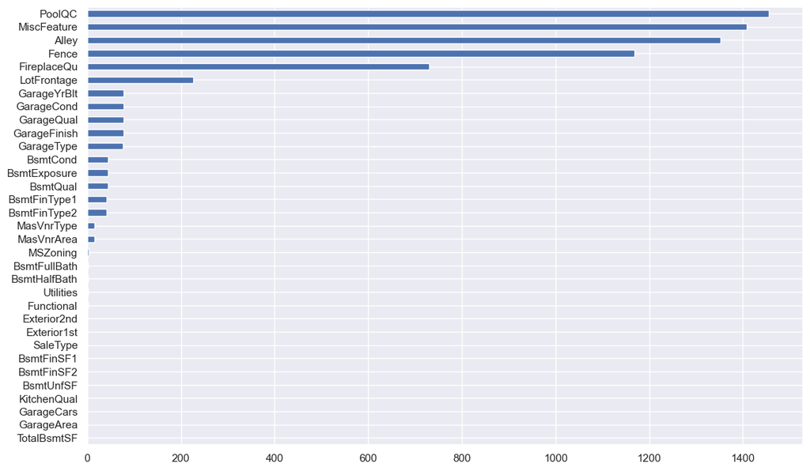

```python
datos_nulos_prueba = datos_prueba.isnull().sum()[datos_prueba.isnull().sum() > 0]
datos_nulos_prueba.sort_values().plot.barh();
```

```python
print('El número de NaN en los datos de prueba:')
print(datos_nulos_prueba.sort_values(ascending = False))
print('El total de NaN:',datos_nulos_prueba.sum())
```

```
El número de NaN en los datos de prueba:
PoolQC          1456
MiscFeature     1408
Alley           1352
Fence           1169
FireplaceQu      730
LotFrontage      227
GarageCond        78
GarageYrBlt       78
GarageQual        78
GarageFinish      78
GarageType        76
BsmtCond          45
BsmtExposure      44
BsmtQual          44
BsmtFinType1      42
BsmtFinType2      42
MasVnrType        16
MasVnrArea        15
MSZoning           4
BsmtFullBath       2
BsmtHalfBath       2
Functional         2
Utilities          2
GarageCars         1
GarageArea         1
TotalBsmtSF        1
KitchenQual        1
BsmtUnfSF          1
BsmtFinSF2         1
BsmtFinSF1         1
Exterior2nd        1
Exterior1st        1
SaleType           1
dtype: int64
El total de NaN: 7000
```

```python
datos_prueba[datos_nulos_prueba.index].dtypes.sort_values()
```

```
TotalBsmtSF     float64
BsmtUnfSF       float64
BsmtFinSF2      float64
BsmtFinSF1      float64
GarageYrBlt     float64
BsmtFullBath    float64
GarageCars      float64
BsmtHalfBath    float64
GarageArea      float64
LotFrontage     float64
MasVnrArea      float64
GarageQual       object
GarageCond       object
GarageType       object
PoolQC           object
FireplaceQu      object
Fence            object
Functional       object
GarageFinish     object
MSZoning         object
MiscFeature      object
BsmtFinType2     object
BsmtFinType1     object
BsmtExposure     object
BsmtCond         object
BsmtQual         object
MasVnrType       object
Exterior2nd      object
Exterior1st      object
Utilities        object
Alley            object
KitchenQual      object
SaleType         object
dtype: object
```

En el caso de los datos de prueba, se observa un mayor número de NaN, llegando a tener 7000 valores faltantes, sin embargo la mayor concentración de estos datos son las mismas variables que en los datos de entrenamiento.

### Reemplazando los NaN conocidos

Según la información del conjunto de datos, muchas de las variables categóricas contienen NaN como la inexistencia de aquel atributo en la casa, por ende el primer paso de la limpieza de datos será reemplazar la primera parte de NaN como un dato de falta de atributo, es decir, **None**:

```python
# Creando una lista con las variables que tienen NA como información:
NA_variables = ['Alley',
                'BsmtQual',
                'BsmtCond',
                'BsmtExposure',
                'BsmtFinType1',
                'BsmtFinType2',
                'FireplaceQu',
                'GarageType',
                'GarageFinish',
                'GarageQual',
                'GarageCond',
                'PoolQC',
                'Fence',
                'MiscFeature']

# Función para reemplazar cada NaN por None
def NaN_por_None(datos):
    datos = datos
    for i in NA_variables:
        datos.loc[datos[i].isnull(),i] = 'None'
    return datos

NaN_por_None(datos_entrenamiento).isnull().sum()[datos_entrenamiento.isnull().sum() > 0]
```

```
LotFrontage    259
MasVnrType       8
MasVnrArea       8
Electrical       1
GarageYrBlt     81
dtype: int64
```

```python
NaN_por_None(datos_prueba).isnull().sum()[datos_prueba.isnull().sum() > 0]
```

```
MSZoning          4
LotFrontage     227
Utilities         2
Exterior1st       1
Exterior2nd       1
MasVnrType       16
MasVnrArea       15
BsmtFinSF1        1
BsmtFinSF2        1
BsmtUnfSF         1
TotalBsmtSF       1
BsmtFullBath      2
BsmtHalfBath      2
KitchenQual       1
Functional        2
GarageYrBlt      78
GarageCars        1
GarageArea        1
SaleType          1
dtype: int64
```

Ahora trataré por separado a la variable **GarageYrBlt**, dado que representa la fecha de creación del garage de las casas, no todas tienen uno, por lo que el NaN también representa la falta del atributo. Para ello, primero cambiaré el tipo de la variable y luego lo seccionaré:

```python
# Revisando el mínimo y el máximo de la variable
print('Datos de entrenamiento:')
print('El mínimo:',datos_entrenamiento['GarageYrBlt'].min())
print('El máximo:',datos_entrenamiento['GarageYrBlt'].max())

print('\n')
# En los datos de prueba:
print('Datos de prueba:')
print('El mínimo:',datos_prueba['GarageYrBlt'].min())
print('El máximo:',datos_prueba['GarageYrBlt'].max())
```

```
Datos de entrenamiento:
El mínimo: 1900.0
El máximo: 2010.0


Datos de prueba:
El mínimo: 1895.0
El máximo: 2207.0
```

```python
# Arreglando ese 2207
datos_prueba.loc[datos_prueba['GarageYrBlt'] > 2010,'GarageYrBlt'] = 2007

# Generando los intervalos
bins = [1890,
        1900,
        1910,
        1920,
        1930,
        1940,
        1950,
        1960,
        1970,
        1980,
        1990,
        2000,
        2010,
        2020]

# Generando las etiquetas
etiquetas = ['1890s',
             '1900s',
             '1910s',
             '1920s',
             '1930s',
             '1940s',
             '1950s',
             '1960s',
             '1970s',
             '1980s',
             '1990s',
             '2000s',
             '2010s']

# Modificando la variable en ambos conjuntos
datos_entrenamiento['GarageYrBlt'] = pd.cut(datos_entrenamiento['GarageYrBlt'],bins=bins,labels=etiquetas)
datos_prueba['GarageYrBlt'] = pd.cut(datos_prueba['GarageYrBlt'],bins=bins,labels=etiquetas)

# Cambiando el tipo de la variable para hacer el cambio
datos_entrenamiento['GarageYrBlt'] = datos_entrenamiento['GarageYrBlt'].astype('str')
datos_prueba['GarageYrBlt'] = datos_prueba['GarageYrBlt'].astype('str')

# Cambiando los NaN por None
datos_entrenamiento.loc[datos_entrenamiento['GarageYrBlt'] == 'nan','GarageYrBlt'] = 'None'
datos_prueba.loc[datos_prueba['GarageYrBlt'] == 'nan','GarageYrBlt'] = 'None'
```

```python
datos_entrenamiento.isnull().sum()[datos_entrenamiento.isnull().sum() > 0]
```

```
LotFrontage    259
MasVnrType       8
MasVnrArea       8
Electrical       1
dtype: int64
```

```python
datos_prueba.isnull().sum()[datos_prueba.isnull().sum() > 0]
```

```
MSZoning          4
LotFrontage     227
Utilities         2
Exterior1st       1
Exterior2nd       1
MasVnrType       16
MasVnrArea       15
BsmtFinSF1        1
BsmtFinSF2        1
BsmtUnfSF         1
TotalBsmtSF       1
BsmtFullBath      2
BsmtHalfBath      2
KitchenQual       1
Functional        2
GarageCars        1
GarageArea        1
SaleType          1
dtype: int64
```

Una vez hecho el reemplazo, se puede ver que el número de NaN se ha reducido considerablemente, ahora queda el resto de NaN desconocidos por reemplazar.

### Reemplazando NaN desconocidos

#### Variables Numéricas

```python
# Actualizando las variables con las variables con NaN
datos_nulos_entrenamiento = datos_entrenamiento.isnull().sum()[datos_entrenamiento.isnull().sum() > 0]
datos_nulos_prueba = datos_prueba.isnull().sum()[datos_prueba.isnull().sum() > 0]

# Observando las variables que quedan con NaN en los datos de entrenamiento
print('Datos de entrenamiento:')
print(datos_entrenamiento[datos_nulos_entrenamiento.index].dtypes.sort_values())
print('\n')
print('Datos de prueba')
print(datos_prueba[datos_nulos_prueba.index].dtypes.sort_values())
```

```
Datos de entrenamiento:
LotFrontage    float64
MasVnrArea     float64
MasVnrType      object
Electrical      object
dtype: object


Datos de prueba
BsmtFinSF2      float64
LotFrontage     float64
GarageCars      float64
BsmtHalfBath    float64
MasVnrArea      float64
BsmtFinSF1      float64
GarageArea      float64
BsmtUnfSF       float64
TotalBsmtSF     float64
BsmtFullBath    float64
Functional       object
KitchenQual      object
MSZoning         object
Exterior2nd      object
Exterior1st      object
Utilities        object
MasVnrType       object
SaleType         object
dtype: object
```

Dado que el imputador solo funciona con datos numéricos, selecciono solo las variables numéricas:

```python
datos_entrenamiento.select_dtypes(exclude = 'object').head()
```

|  | Id | MSSubClass | LotFrontage | LotArea | OverallQual | OverallCond | YearBuilt | YearRemodAdd | MasVnrArea | BsmtFinSF1 | BsmtFinSF2 | BsmtUnfSF | TotalBsmtSF | 1stFlrSF | 2ndFlrSF | LowQualFinSF | GrLivArea | BsmtFullBath | BsmtHalfBath | FullBath | HalfBath | BedroomAbvGr | KitchenAbvGr | TotRmsAbvGrd | Fireplaces | GarageCars | GarageArea | WoodDeckSF | OpenPorchSF | … |
| --- | --- | --- | --- | --- | --- | --- | --- | --- | --- | --- | --- | --- | --- | --- | --- | --- | --- | --- | --- | --- | --- | --- | --- | --- | --- | --- | --- | --- | --- | --- |
| 0 | 1 | 60 | 65.0 | 8450 | 7 | 5 | 2003 | 2003 | 196.0 | 706 | 0 | 150 | 856 | 856 | 854 | 0 | 1710 | 1 | 0 | 2 | 1 | 3 | 1 | 8 | 0 | 2 | 548 | 0 | 61 | … |
| 1 | 2 | 20 | 80.0 | 9600 | 6 | 8 | 1976 | 1976 | 0.0 | 978 | 0 | 284 | 1262 | 1262 | 0 | 0 | 1262 | 0 | 1 | 2 | 0 | 3 | 1 | 6 | 1 | 2 | 460 | 298 | 0 | … |
| 2 | 3 | 60 | 68.0 | 11250 | 7 | 5 | 2001 | 2002 | 162.0 | 486 | 0 | 434 | 920 | 920 | 866 | 0 | 1786 | 1 | 0 | 2 | 1 | 3 | 1 | 6 | 1 | 2 | 608 | 0 | 42 | … |
| 3 | 4 | 70 | 60.0 | 9550 | 7 | 5 | 1915 | 1970 | 0.0 | 216 | 0 | 540 | 756 | 961 | 756 | 0 | 1717 | 1 | 0 | 1 | 0 | 3 | 1 | 7 | 1 | 3 | 642 | 0 | 35 | … |
| 4 | 5 | 60 | 84.0 | 14260 | 8 | 5 | 2000 | 2000 | 350.0 | 655 | 0 | 490 | 1145 | 1145 | 1053 | 0 | 2198 | 1 | 0 | 2 | 1 | 4 | 1 | 9 | 1 | 3 | 836 | 192 | 84 | … |

```python
datos_prueba.select_dtypes(exclude = 'object').head()
```

|  | Id | MSSubClass | LotFrontage | LotArea | OverallQual | OverallCond | YearBuilt | YearRemodAdd | MasVnrArea | BsmtFinSF1 | BsmtFinSF2 | BsmtUnfSF | TotalBsmtSF | 1stFlrSF | 2ndFlrSF | LowQualFinSF | GrLivArea | BsmtFullBath | BsmtHalfBath | FullBath | HalfBath | BedroomAbvGr | KitchenAbvGr | TotRmsAbvGrd | Fireplaces | GarageCars | GarageArea | WoodDeckSF | OpenPorchSF | … |
| --- | --- | --- | --- | --- | --- | --- | --- | --- | --- | --- | --- | --- | --- | --- | --- | --- | --- | --- | --- | --- | --- | --- | --- | --- | --- | --- | --- | --- | --- | --- |
| 0 | 1461 | 20 | 80.0 | 11622 | 5 | 6 | 1961 | 1961 | 0.0 | 468.0 | 144.0 | 270.0 | 882.0 | 896 | 0 | 0 | 896 | 0.0 | 0.0 | 1 | 0 | 2 | 1 | 5 | 0 | 1.0 | 730.0 | 140 | 0 | … |
| 1 | 1462 | 20 | 81.0 | 14267 | 6 | 6 | 1958 | 1958 | 108.0 | 923.0 | 0.0 | 406.0 | 1329.0 | 1329 | 0 | 0 | 1329 | 0.0 | 0.0 | 1 | 1 | 3 | 1 | 6 | 0 | 1.0 | 312.0 | 393 | 36 | … |
| 2 | 1463 | 60 | 74.0 | 13830 | 5 | 5 | 1997 | 1998 | 0.0 | 791.0 | 0.0 | 137.0 | 928.0 | 928 | 701 | 0 | 1629 | 0.0 | 0.0 | 2 | 1 | 3 | 1 | 6 | 1 | 2.0 | 482.0 | 212 | 34 | … |
| 3 | 1464 | 60 | 78.0 | 9978 | 6 | 6 | 1998 | 1998 | 20.0 | 602.0 | 0.0 | 324.0 | 926.0 | 926 | 678 | 0 | 1604 | 0.0 | 0.0 | 2 | 1 | 3 | 1 | 7 | 1 | 2.0 | 470.0 | 360 | 36 | … |
| 4 | 1465 | 120 | 43.0 | 5005 | 8 | 5 | 1992 | 1992 | 0.0 | 263.0 | 0.0 | 1017.0 | 1280.0 | 1280 | 0 | 0 | 1280 | 0.0 | 0.0 | 2 | 0 | 2 | 1 | 5 | 0 | 2.0 | 506.0 | 0 | 82 | … |

Procedo a crear el imputador que funcionará mediante el algoritmo del **Bosque Aleatorio del tipo regresor**, para tener datos con el menor sesgo posible:

```python
# Definiendo el imputador
imputador = IterativeImputer(estimator          = RandomForestRegressor(),
                             random_state       = 0,
                             imputation_order   = 'roman',
                             n_nearest_features = 5,
                             max_iter           = 10,
                             tol                = 0.01)
```

Ahora procedo a crear una función para automatizar la imputación de NaN para los valores numéricos:

```python
def imputacion_numerica(datos,variables):
    df                  = datos.copy()
    df_num              = df.select_dtypes(exclude = 'object')
    df_imputado_valores = imputador.fit_transform(df_num)
    df_imputado         = pd.DataFrame(df_imputado_valores,columns = df_num.columns)
    datos[variables]    = df_imputado[variables].round().astype('int64')
```

Ahora mediante el uso de ciclos For, imputaré los NaN de las variables numéricas de ambos conjuntos de datos:

```python
# Las variables a imputar de los datos de entrenamiento
var_num_entrenamiento = datos_entrenamiento[datos_nulos_entrenamiento.index].select_dtypes(np.number).isnull().sum().index

# Las variables a imputar de los datos de prueba
var_num_prueba = datos_prueba[datos_nulos_prueba.index].select_dtypes(np.number).isnull().sum().index

# Imputando para ambos conjuntos
for i,j in zip([datos_entrenamiento,datos_prueba],[var_num_entrenamiento,var_num_prueba]):
    imputacion_numerica(i,j)
```

```python
print('Datos nulos en los datos de entrenamiento:')
print(datos_entrenamiento.isnull().sum()[datos_entrenamiento.isnull().sum() > 0])
print('\n')
print('Datos nulos en los datos de prueba:')
print(datos_prueba.isnull().sum()[datos_prueba.isnull().sum() > 0])
```

```
Datos nulos en los datos de entrenamiento:
MasVnrType    8
Electrical    1
dtype: int64


Datos nulos en los datos de prueba:
MSZoning        4
Utilities       2
Exterior1st     1
Exterior2nd     1
MasVnrType     16
KitchenQual     1
Functional      2
SaleType        1
dtype: int64
```

Teniendo listo ambas imputaciones, me queda finalmente la imputación de NaN en variables categóricas.

#### Variables Categóricas

Para empezar la imputación, primero crearé un codificador para las variables categóricas, dado que los imputadores aceptan solo números en el proceso, tal como mencioné anteriormente. Para ello, utilizaré el **LabelEncoder**, y luego crearé una función que me automatice la imputación como lo hice anteriormente:

```python
# Creando el codificador
codificador = LabelEncoder()

# Creando otro imputador para las variables categóricas
imputador_cat = IterativeImputer(estimator          = RandomForestClassifier(),
                                 random_state       = 0,
                                 imputation_order   = 'roman',
                                 n_nearest_features = 5,
                                 max_iter           = 10)

# Función para imputar los NaN pero para variables categóricas
def imputacion_categorica(datos,variable):
    df                    = datos.copy()
    df[variable]          = df[variable].pipe(lambda x: pd.Series(codificador.fit_transform(x[x.notnull()]),index = x[x.notnull()].index))
    df_num                = df.select_dtypes(exclude = 'object')
    df_imputado_valores   = imputador_cat.fit_transform(df_num)
    df_imputado           = pd.DataFrame(df_imputado_valores,columns = df_num.columns)
    df_imputado[variable] = df_imputado[variable].astype('int64')
    df_imputado[variable] = df_imputado[variable].pipe(lambda x: pd.Series(codificador.inverse_transform(x)))
    datos[variable]       = df_imputado[variable]
```

```python
# Imputando los datos de entrenamiento
var_cat_entrenamiento = datos_entrenamiento.isnull().sum()[datos_entrenamiento.isnull().sum() > 0].index

for i in var_cat_entrenamiento:
    imputacion_categorica(datos_entrenamiento,i)
```

```python
print('Cantidad de datos nulos en los datos de entrenamiento:')
print(datos_entrenamiento.isnull().sum().sum())
```

```
Cantidad de datos nulos en los datos de entrenamiento:
0
```

```python
# Imputando los datos de prubea
var_cat_prueba = datos_prueba.isnull().sum()[datos_prueba.isnull().sum() > 0].index

for i in var_cat_prueba:
    imputacion_categorica(datos_prueba,i)
```

```python
print('Cantidad de datos nulos en los datos de prueba:')
print(datos_prueba.isnull().sum().sum())
```

```
Cantidad de datos nulos en los datos de prueba:
0
```

Ya teniendo limpios los datos, procedo a ver la distribuciones de estos.

## Distribución de los datos

Para empezar, la primera distribución a observar va a ser la de la variable a predecir, la cual es la más importante:

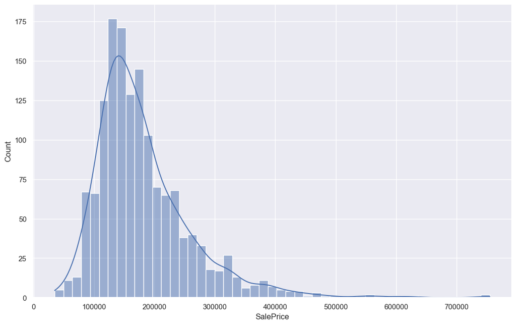

```python
sns.histplot(data = datos_entrenamiento,
             x    = 'SalePrice',
             kde  = True);
```

Se puede ver que la distribución es asimétrica con cola positiva, esto quiere decir que hay **una alta probabilidad** de que si desarrollo un modelo de machine learning con la variable de esta manera, **las predicciones puedan estar sesgadas**. La solución a ello es cambiar la escala de la variable o normalizarla también. Voy a revisar que tal las demás variables:

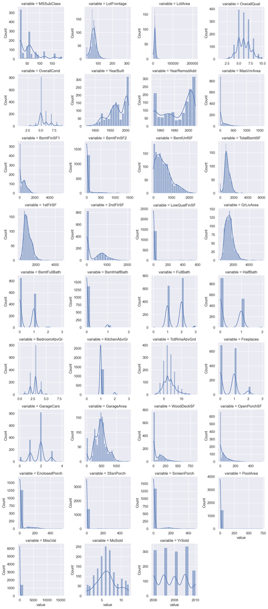

```python
f = pd.melt(datos_entrenamiento,value_vars = datos_entrenamiento.select_dtypes(np.number).drop(['Id','SalePrice'],axis = 1))
g = sns.FacetGrid(f,col = 'variable',col_wrap=4,sharex = False,sharey = False)
g.map(sns.histplot,'value',kde = True);
```

Aqui se observa que las variables también tienen, en su mayoría, distribuciones asimétricas, además ya a primera vista se ve que en las variables discretas hay un desbalance de clases, por lo tanto esto ya me muestra que tengo escalar los datos. Ahora procedo a ver la distribución de las variables categóricas:

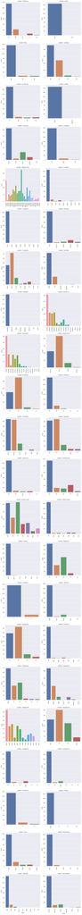

```python
def countplot(x,**kwargs):
    sns.countplot(x = x)
    x = plt.xticks(rotation=90)

f = pd.melt(datos_entrenamiento,value_vars = datos_entrenamiento.select_dtypes('object'))
g = sns.FacetGrid(f,col = 'variable',col_wrap=2,sharex=False,sharey=False,height = 6,aspect = 1)
g.map(countplot,'value');
```

Se ve que también hay variables categóricas con clases completamente desbalanceadas, por lo que esto refuerza más mi idea de un posible sesgo entre las variables, por lo que definitvamente abrá que normalizar las variables. Sin embargo antes de ello, y para evitar hacer trabajo demás, pasaré a ver primero las correlaciones que hay con la variable a predecir, con ello, podré ver cuales variables tendré que normalizar y/o escalar junto a la variable objetivo misma.

## Correlación de los datos

### Variables numéricas

Para empezar, comenzaré primero con las variables numéricas, ya que son más faciles de estimar y generar la matríz de correlación. Debido a la existencia de variables numéricas continuas como discretas, la correlación más adecuada para este caso será la correlación de Spearman:

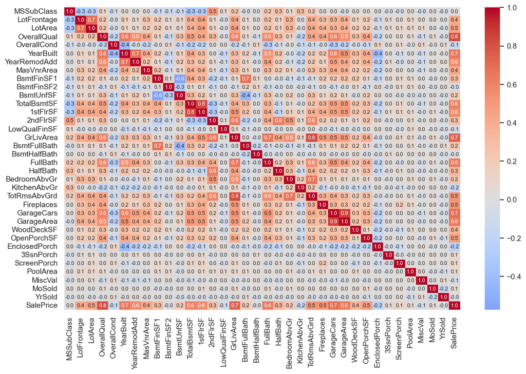

```python
# Definiendo una variable que contenga las variables numéricas del conjunto de datos de entrenamientp:
datos_num_entrenamiento = datos_entrenamiento.drop('Id',axis = 1).select_dtypes(exclude = 'object')

# Generando la matriz de correlación de Spearman
matriz_corr = datos_num_entrenamiento.corr(method = 'spearman')

# Generando el mapa de calor para la matriz de correlación
sns.heatmap(data      = matriz_corr,
            center    = 0,
            cmap      = 'coolwarm',
            annot     = True,
            fmt       = '.1f',
            annot_kws = {"fontsize":8});
```

Se observa que las correlaciones se dan más a la esquina superior izquierda, además de los bordes inferior y a la derecha, precisamente esos bordes representan a la variable a predecir, procedo a extraer los valores que conciernen a esta variable:

```python
correlaciones_var_objetivo = matriz_corr['SalePrice'].drop('SalePrice')
correlaciones_var_objetivo.sort_values(ascending = False)
```

```
OverallQual      0.809829
GrLivArea        0.731310
GarageCars       0.690711
YearBuilt        0.652682
GarageArea       0.649379
FullBath         0.635957
TotalBsmtSF      0.602725
1stFlrSF         0.575408
YearRemodAdd     0.571159
TotRmsAbvGrd     0.532586
Fireplaces       0.519247
OpenPorchSF      0.477561
LotArea          0.456461
MasVnrArea       0.423831
LotFrontage      0.408051
WoodDeckSF       0.353802
HalfBath         0.343008
BsmtFinSF1       0.301871
2ndFlrSF         0.293598
BedroomAbvGr     0.234907
BsmtFullBath     0.225125
BsmtUnfSF        0.185197
ScreenPorch      0.100070
MoSold           0.069432
3SsnPorch        0.065440
PoolArea         0.058453
MSSubClass       0.007192
BsmtHalfBath    -0.012189
YrSold          -0.029899
BsmtFinSF2      -0.038806
MiscVal         -0.062727
LowQualFinSF    -0.067719
OverallCond     -0.129325
KitchenAbvGr    -0.164826
EnclosedPorch   -0.218394
Name: SalePrice, dtype: float64
```

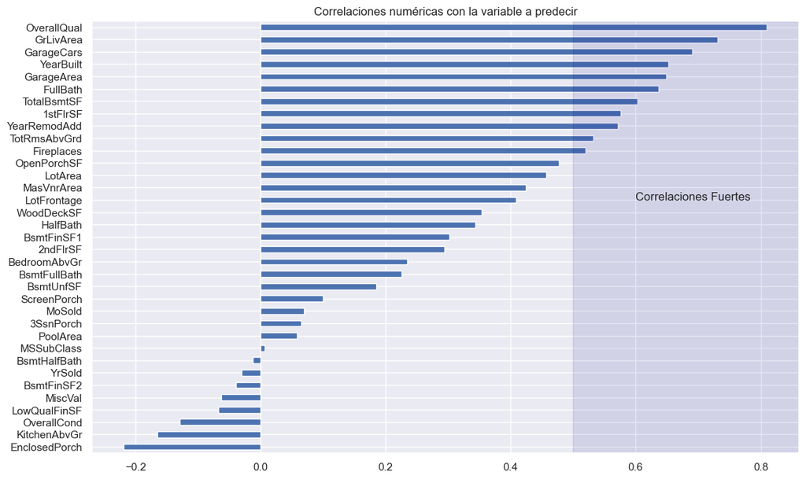

```python
correlaciones_var_objetivo.sort_values().plot.barh()
ax = plt.gca()
xlim = ax.get_xlim()
plt.axvspan(xmin=0.5,xmax = xlim[1],alpha = 0.1,color = 'darkblue')
plt.title('Correlaciones numéricas con la variable a predecir')
plt.text(x = 0.6,y = 20,s = 'Correlaciones Fuertes')
plt.xlim(xlim);
```

Aquí se ve todas las correlaciones que tiene la variable objetivo con las demás variables del conjunto de datos, excepto con la variable 'Id', que es solo un identificador, no es relevante, y la variable objetivo misma, cuya correlación siempre será 1. A partir de aquí, y bajo mi criterio, **las correlaciones más importantes serán las que sean mayor o igual a 0.5 y menor o igual a -0.5**, dado que son las más lejanas a cero, es decir, las más correlacionadas con la variable a predecir:

```python
correlaciones_fuertes = correlaciones_var_objetivo[(correlaciones_var_objetivo >= 0.5) | (correlaciones_var_objetivo <= -0.5)]
correlaciones_fuertes.sort_values(ascending = False)
```

```
OverallQual     0.809829
GrLivArea       0.731310
GarageCars      0.690711
YearBuilt       0.652682
GarageArea      0.649379
FullBath        0.635957
TotalBsmtSF     0.602725
1stFlrSF        0.575408
YearRemodAdd    0.571159
TotRmsAbvGrd    0.532586
Fireplaces      0.519247
Name: SalePrice, dtype: float64
```

Se puede observar que la de mayor correlación tiene valor de 0.8, que es una correlación muy alta, sin embargo, cabe destacar que esto no implica en lo absoluto causalidad. Para observar mejor esta correlación, graficaré:

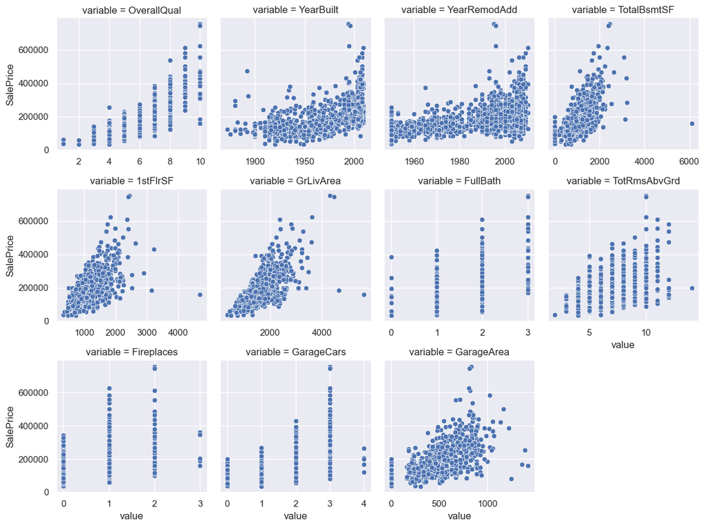

```python
f = pd.melt(datos_entrenamiento,id_vars = 'SalePrice',value_vars = datos_entrenamiento[correlaciones_fuertes.index])
g = sns.FacetGrid(f,col = 'variable',col_wrap = 4,sharex = False, sharey = True)
g.map(sns.scatterplot,'value','SalePrice');
```

A partir de aquí se puede ver que hay patrones de linealidad, aunque en algunas variables no sea tan notorio aquello, además de dar cuenta de la **presencia de outliers en los datos**, otro problema con que hay que lidiar. Con esto, uno puede también querer saber que tanto covarían precisamente estas variables con la objetivo:

```python
# Gerando la matriz de covarianzas
covarianzas = datos_entrenamiento.cov()

# Seleccionando las covarianzas de la variable objetivo con las correlaciones más fuertes de estas
covarianzas['SalePrice'][correlaciones_fuertes.index]
```

```
OverallQual     8.690413e+04
YearBuilt       1.254637e+06
YearRemodAdd    8.317079e+05
TotalBsmtSF     2.138442e+07
1stFlrSF        1.860663e+07
GrLivArea       2.958187e+07
FullBath        2.453808e+04
TotRmsAbvGrd    6.891717e+04
Fireplaces      2.391325e+04
GarageCars      3.802018e+04
GarageArea      1.058910e+07
Name: SalePrice, dtype: float64
```

De aquí la información más importante que se puede extraer de las covarianzas, es que **la variable objetivo covaría positivamente con las correlaciones más altas**. Las magnitudes son dificiles de expresar y generalmente no tienen un significado único, por lo que las ignoraré en este trabajo. Ahora voy a ver las correlaciones con las variables categóricas:

### Variables categóricas

Dado que la correlación será entre una variable numéricas y otras variables categóricas, aquí se procede a utilizar el test **ANOVA** o el análisis de varianzas, osea un test de hipótesis, para ello, definiré una variable que contenga todas las variables categóricas del conjunto de datos:

```python
datos_cat_entrenamiento = datos_entrenamiento.select_dtypes('object')
datos_cat_entrenamiento.head()
```

|  | MSZoning | Street | Alley | LotShape | LandContour | Utilities | LotConfig | LandSlope | Neighborhood | Condition1 | Condition2 | BldgType | HouseStyle | RoofStyle | RoofMatl | Exterior1st | Exterior2nd | MasVnrType | ExterQual | ExterCond | Foundation | BsmtQual | BsmtCond | BsmtExposure | BsmtFinType1 | BsmtFinType2 | Heating | HeatingQC | CentralAir | … |
| --- | --- | --- | --- | --- | --- | --- | --- | --- | --- | --- | --- | --- | --- | --- | --- | --- | --- | --- | --- | --- | --- | --- | --- | --- | --- | --- | --- | --- | --- | --- |
| 0 | RL | Pave | None | Reg | Lvl | AllPub | Inside | Gtl | CollgCr | Norm | Norm | 1Fam | 2Story | Gable | CompShg | VinylSd | VinylSd | BrkFace | Gd | TA | PConc | Gd | TA | No | GLQ | Unf | GasA | Ex | Y | … |
| 1 | RL | Pave | None | Reg | Lvl | AllPub | FR2 | Gtl | Veenker | Feedr | Norm | 1Fam | 1Story | Gable | CompShg | MetalSd | MetalSd | None | TA | TA | CBlock | Gd | TA | Gd | ALQ | Unf | GasA | Ex | Y | … |
| 2 | RL | Pave | None | IR1 | Lvl | AllPub | Inside | Gtl | CollgCr | Norm | Norm | 1Fam | 2Story | Gable | CompShg | VinylSd | VinylSd | BrkFace | Gd | TA | PConc | Gd | TA | Mn | GLQ | Unf | GasA | Ex | Y | … |
| 3 | RL | Pave | None | IR1 | Lvl | AllPub | Corner | Gtl | Crawfor | Norm | Norm | 1Fam | 2Story | Gable | CompShg | Wd Sdng | Wd Shng | None | TA | TA | BrkTil | TA | Gd | No | ALQ | Unf | GasA | Gd | Y | … |
| 4 | RL | Pave | None | IR1 | Lvl | AllPub | FR2 | Gtl | NoRidge | Norm | Norm | 1Fam | 2Story | Gable | CompShg | VinylSd | VinylSd | BrkFace | Gd | TA | PConc | Gd | TA | Av | GLQ | Unf | GasA | Ex | Y | … |

Teniendo ya las variables categóricas, procedo a transformar la variable objetivo, para tener la normalidad para el ANOVA:

```python
# Creando una copia para usarla en el ANOVA
df_para_ANOVA = datos_entrenamiento.copy()

# Definiendo el transformador de YeoJohnson
transformador = PowerTransformer(standardize = True)

# Transformando la variable
df_para_ANOVA['SalePrice'] = transformador.fit_transform(df_para_ANOVA['SalePrice'].values.reshape(-1,1))
```

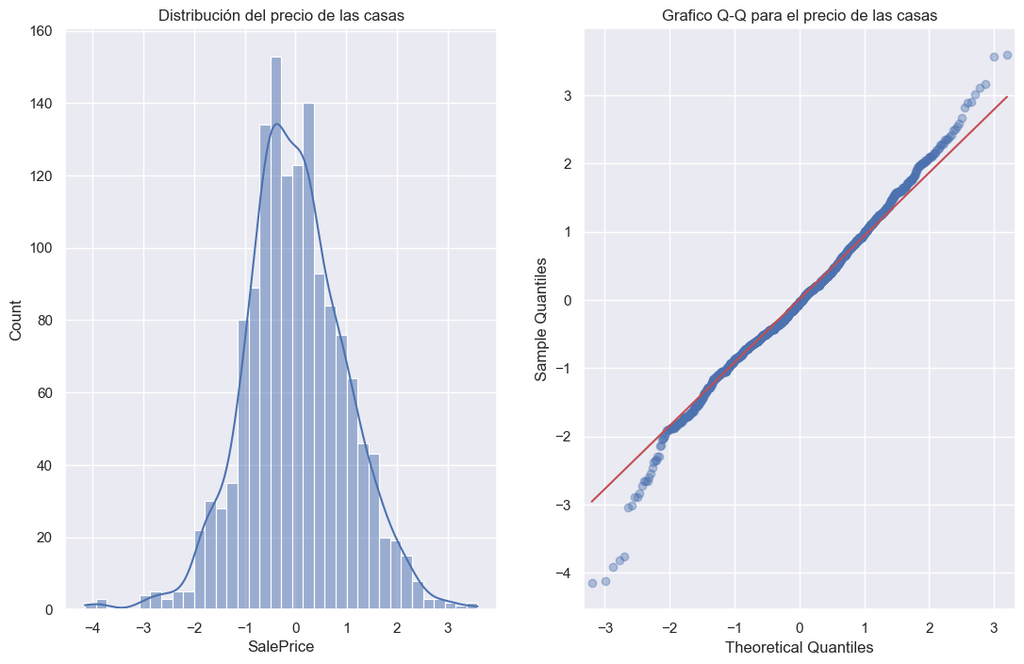

```python
# Comprobando la normalidad
fig,ax = plt.subplots(1,2)

sns.histplot(data = df_para_ANOVA,
             x    = 'SalePrice',
             kde  = True,
             ax   = ax[0])
ax[0].set_title('Distribución del precio de las casas')

sm.qqplot(data  = df_para_ANOVA['SalePrice'],
          fit   = True,
          line  = 'q',
          alpha = 0.4,
          lw    = 2,
          ax    = ax[1])
ax[1].set_title('Grafico Q-Q para el precio de las casas');
```

```python
df_para_ANOVA['SalePrice'].skew()
```

```
-0.008653670817198679
```

Ahora procedo a ver la distribución de las variables categóricas con la variable objetivo normalizada:

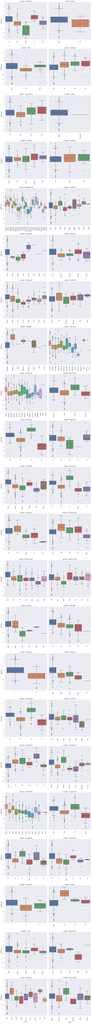

```python
def boxplot(x,y,**kwargs):
    sns.boxplot(x = x, y = y)
    plt.xticks(rotation=90)

f = pd.melt(df_para_ANOVA,id_vars = 'SalePrice',value_vars = df_para_ANOVA[datos_cat_entrenamiento.columns])
g = sns.FacetGrid(f,col = 'variable',col_wrap = 2,sharex = False,aspect = 1,height = 6)
g.map(boxplot,'value','SalePrice');
```

De lo anterior, se puede divisar a simple vista la alta presencia de outliers en los datos, como también que variables pueden tener una correlación importante con la variable objetivo, para verificar esto, procedo a realizar ahora el test de ANOVA:

```python
def ANOVA(datos,var_num,var_cat):
    f_score = stats.f_oneway(*datos.groupby(var_cat)[var_num].apply(list))[0]
    p_valor = stats.f_oneway(*datos.groupby(var_cat)[var_num].apply(list))[1]
    return [f_score,p_valor]
```

```python
var_cat_corr = []
for i in df_para_ANOVA.select_dtypes('object').columns:
    p_valor = ANOVA(df_para_ANOVA,'SalePrice',i)[1]

    if p_valor < 0.05:
        var_cat_corr.append(i)
```

```python
p_valores = []
for i in df_para_ANOVA.select_dtypes('object').columns:
    p_valor = ANOVA(df_para_ANOVA,'SalePrice',i)[1]

    if p_valor < 0.05:
        p_valores.append(p_valor)
```

```python
df_PVal = pd.DataFrame({'Variable':var_cat_corr,'Valor P':p_valores})
np.log(1/df_PVal.pivot_table(values='Valor P',index = 'Variable').sort_values(by = 'Valor P')).head()
```

| Variable | Valor P |
| --- | --- |
| Neighborhood | 553.986628 |
| ExterQual | 439.676714 |
| BsmtQual | 425.765012 |
| KitchenQual | 423.067110 |
| GarageFinish | 349.222185 |

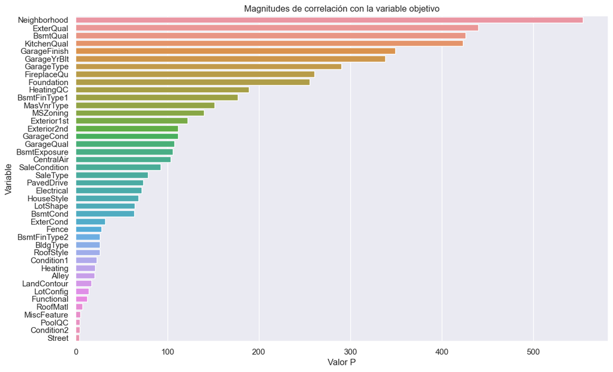

```python
sns.barplot(data = df_PVal.sort_values(by = 'Valor P',ascending = True),
            x    = np.log(1/df_PVal.sort_values(by = 'Valor P',ascending = True)['Valor P']),
            y    = 'Variable')
plt.title('Magnitudes de correlación con la variable objetivo');
```

## Ingeniería de atributos

Ya teniendo las correlaciones de las variables numéricas y variables categóricas, procedo a hacer la ingeniería de atributos para tener las mejores variables predictoras:

```python
# Juntando las listas con las variables correlacionadas
variables_correlacion = correlaciones_fuertes.index.to_list() + var_cat_corr + ['SalePrice']

# Generando una nueva lista para votar las variables que no me sirve y sin alterar el orden original del dataset
variables_drop = datos_entrenamiento.drop(variables_correlacion,axis = 1).columns.to_list()

# Hago una nueva copia de los conjuntos de datos
df_entramiento_copia = datos_entrenamiento.copy()
df_prueba_copia = datos_prueba.copy()

# Quito las variables que no me sirven en la predicción
df_entramiento_copia = df_entramiento_copia.drop(variables_drop,axis = 1)
df_prueba_copia = df_prueba_copia.drop(variables_drop,axis = 1)

# Reviso ambos conjuntos
df_entramiento_copia.head()
```

|  | MSZoning | Street | Alley | LotShape | LandContour | LotConfig | Neighborhood | Condition1 | Condition2 | BldgType | HouseStyle | OverallQual | YearBuilt | YearRemodAdd | RoofStyle | RoofMatl | Exterior1st | Exterior2nd | MasVnrType | ExterQual | ExterCond | Foundation | BsmtQual | BsmtCond | BsmtExposure | BsmtFinType1 | BsmtFinType2 | TotalBsmtSF | Heating | … |
| --- | --- | --- | --- | --- | --- | --- | --- | --- | --- | --- | --- | --- | --- | --- | --- | --- | --- | --- | --- | --- | --- | --- | --- | --- | --- | --- | --- | --- | --- | --- |
| 0 | RL | Pave | None | Reg | Lvl | Inside | CollgCr | Norm | Norm | 1Fam | 2Story | 7 | 2003 | 2003 | Gable | CompShg | VinylSd | VinylSd | BrkFace | Gd | TA | PConc | Gd | TA | No | GLQ | Unf | 856 | GasA | … |
| 1 | RL | Pave | None | Reg | Lvl | FR2 | Veenker | Feedr | Norm | 1Fam | 1Story | 6 | 1976 | 1976 | Gable | CompShg | MetalSd | MetalSd | None | TA | TA | CBlock | Gd | TA | Gd | ALQ | Unf | 1262 | GasA | … |
| 2 | RL | Pave | None | IR1 | Lvl | Inside | CollgCr | Norm | Norm | 1Fam | 2Story | 7 | 2001 | 2002 | Gable | CompShg | VinylSd | VinylSd | BrkFace | Gd | TA | PConc | Gd | TA | Mn | GLQ | Unf | 920 | GasA | … |
| 3 | RL | Pave | None | IR1 | Lvl | Corner | Crawfor | Norm | Norm | 1Fam | 2Story | 7 | 1915 | 1970 | Gable | CompShg | Wd Sdng | Wd Shng | None | TA | TA | BrkTil | TA | Gd | No | ALQ | Unf | 756 | GasA | … |
| 4 | RL | Pave | None | IR1 | Lvl | FR2 | NoRidge | Norm | Norm | 1Fam | 2Story | 8 | 2000 | 2000 | Gable | CompShg | VinylSd | VinylSd | BrkFace | Gd | TA | PConc | Gd | TA | Av | GLQ | Unf | 1145 | GasA | … |

```python
df_prueba_copia.head()
```

|  | MSZoning | Street | Alley | LotShape | LandContour | LotConfig | Neighborhood | Condition1 | Condition2 | BldgType | HouseStyle | OverallQual | YearBuilt | YearRemodAdd | RoofStyle | RoofMatl | Exterior1st | Exterior2nd | MasVnrType | ExterQual | ExterCond | Foundation | BsmtQual | BsmtCond | BsmtExposure | BsmtFinType1 | BsmtFinType2 | TotalBsmtSF | Heating | … |
| --- | --- | --- | --- | --- | --- | --- | --- | --- | --- | --- | --- | --- | --- | --- | --- | --- | --- | --- | --- | --- | --- | --- | --- | --- | --- | --- | --- | --- | --- | --- |
| 0 | RH | Pave | None | Reg | Lvl | Inside | NAmes | Feedr | Norm | 1Fam | 1Story | 5 | 1961 | 1961 | Gable | CompShg | VinylSd | VinylSd | None | TA | TA | CBlock | TA | TA | No | Rec | LwQ | 882 | GasA | … |
| 1 | RL | Pave | None | IR1 | Lvl | Corner | NAmes | Norm | Norm | 1Fam | 1Story | 6 | 1958 | 1958 | Hip | CompShg | Wd Sdng | Wd Sdng | BrkFace | TA | TA | CBlock | TA | TA | No | ALQ | Unf | 1329 | GasA | … |
| 2 | RL | Pave | None | IR1 | Lvl | Inside | Gilbert | Norm | Norm | 1Fam | 2Story | 5 | 1997 | 1998 | Gable | CompShg | VinylSd | VinylSd | None | TA | TA | PConc | Gd | TA | No | GLQ | Unf | 928 | GasA | … |
| 3 | RL | Pave | None | IR1 | Lvl | Inside | Gilbert | Norm | Norm | 1Fam | 2Story | 6 | 1998 | 1998 | Gable | CompShg | VinylSd | VinylSd | BrkFace | TA | TA | PConc | TA | TA | No | GLQ | Unf | 926 | GasA | … |
| 4 | RL | Pave | None | IR1 | HLS | Inside | StoneBr | Norm | Norm | TwnhsE | 1Story | 8 | 1992 | 1992 | Gable | CompShg | HdBoard | HdBoard | None | Gd | TA | PConc | Gd | TA | No | ALQ | Unf | 1280 | GasA | … |

### Fusión de variables cualitativas

```python
def data_reduction(datos):
    # Reductor de clases para MSZoning y LotShape --------------------------------------------------------------------------------------------
    def class_reduction(var,clases_actuales,clase_nueva):
        datos[var].replace(clases_actuales,clase_nueva,inplace = True)

    variables = ['MSZoning','LotShape']
    clases_actuales = [['RH','RL','RP','RM'],['IR1','IR2','IR3']]
    nueva_clase = ['R','IR']

    for i,j,k in zip(variables,clases_actuales,nueva_clase):
        class_reduction(i,j,k)
    #-----------------------------------------------------------------------------------------------------------------------------------------
    # Union de variables sin condicionales ---------------------------------------------------------------------------------------------------
    def var_reduction(datos,var1,var2):
        datos[var1] = datos[var1] + ' & ' + datos[var2]
        datos.rename(columns = {var1:var1 + '_' + var2},inplace = True)
        datos.drop([var2],axis = 1,inplace = True)

    variable_1 = ['LotShape','BldgType','RoofStyle','Heating','SaleType']
    variable_2 = ['LandContour','HouseStyle','RoofMatl','HeatingQC','SaleCondition']
    for i,j in zip(variable_1,variable_2):
        var_reduction(datos,i,j)
    #-----------------------------------------------------------------------------------------------------------------------------------------
    # Unión de variables con condicionales ---------------------------------------------------------------------------------------------------
    def var_reduction_condition(datos,var1,var2):
        datos[var1] = np.where((datos[var1] == datos[var2]), datos[var1], datos[var1] + ' & ' + datos[var2])
        datos.rename(columns = {var1:var1 + '_' + var2},inplace = True)
        datos.drop([var2],axis = 1,inplace = True)

    variable_1 = ['Street','Condition1','Exterior1st','ExterQual','BsmtQual','BsmtFinType1','GarageQual']
    variable_2 = ['Alley','Condition2','Exterior2nd','ExterCond','BsmtCond','BsmtFinType2','GarageCond']

    for i,j in zip(variable_1,variable_2):
        var_reduction_condition(datos,i,j)

    return datos.head()
```

```python
data_reduction(df_entramiento_copia)
```

|  | MSZoning | Street_Alley | LotShape_LandContour | LotConfig | Neighborhood | Condition1_Condition2 | BldgType_HouseStyle | OverallQual | YearBuilt | YearRemodAdd | RoofStyle_RoofMatl | Exterior1st_Exterior2nd | MasVnrType | ExterQual_ExterCond | Foundation | BsmtQual_BsmtCond | BsmtExposure | BsmtFinType1_BsmtFinType2 | TotalBsmtSF | Heating_HeatingQC | CentralAir | Electrical | 1stFlrSF | GrLivArea | FullBath | KitchenQual | TotRmsAbvGrd | Functional | Fireplaces | … |
| --- | --- | --- | --- | --- | --- | --- | --- | --- | --- | --- | --- | --- | --- | --- | --- | --- | --- | --- | --- | --- | --- | --- | --- | --- | --- | --- | --- | --- | --- | --- |
| 0 | R | Pave & None | Reg & Lvl | Inside | CollgCr | Norm | 1Fam & 2Story | 7 | 2003 | 2003 | Gable & CompShg | VinylSd | BrkFace | Gd & TA | PConc | Gd & TA | No | GLQ & Unf | 856 | GasA & Ex | Y | SBrkr | 856 | 1710 | 2 | Gd | 8 | Typ | 0 | … |
| 1 | R | Pave & None | Reg & Lvl | FR2 | Veenker | Feedr & Norm | 1Fam & 1Story | 6 | 1976 | 1976 | Gable & CompShg | MetalSd | None | TA | CBlock | Gd & TA | Gd | ALQ & Unf | 1262 | GasA & Ex | Y | SBrkr | 1262 | 1262 | 2 | TA | 6 | Typ | 1 | … |
| 2 | R | Pave & None | IR & Lvl | Inside | CollgCr | Norm | 1Fam & 2Story | 7 | 2001 | 2002 | Gable & CompShg | VinylSd | BrkFace | Gd & TA | PConc | Gd & TA | Mn | GLQ & Unf | 920 | GasA & Ex | Y | SBrkr | 920 | 1786 | 2 | Gd | 6 | Typ | 1 | … |
| 3 | R | Pave & None | IR & Lvl | Corner | Crawfor | Norm | 1Fam & 2Story | 7 | 1915 | 1970 | Gable & CompShg | Wd Sdng & Wd Shng | None | TA | BrkTil | TA & Gd | No | ALQ & Unf | 756 | GasA & Gd | Y | SBrkr | 961 | 1717 | 1 | Gd | 7 | Typ | 1 | … |
| 4 | R | Pave & None | IR & Lvl | FR2 | NoRidge | Norm | 1Fam & 2Story | 8 | 2000 | 2000 | Gable & CompShg | VinylSd | BrkFace | Gd & TA | PConc | Gd & TA | Av | GLQ & Unf | 1145 | GasA & Ex | Y | SBrkr | 1145 | 2198 | 2 | Gd | 9 | Typ | 1 | … |

```python
len(df_entramiento_copia.columns)
```

```
42
```

```python
data_reduction(df_prueba_copia)
```

|  | MSZoning | Street_Alley | LotShape_LandContour | LotConfig | Neighborhood | Condition1_Condition2 | BldgType_HouseStyle | OverallQual | YearBuilt | YearRemodAdd | RoofStyle_RoofMatl | Exterior1st_Exterior2nd | MasVnrType | ExterQual_ExterCond | Foundation | BsmtQual_BsmtCond | BsmtExposure | BsmtFinType1_BsmtFinType2 | TotalBsmtSF | Heating_HeatingQC | CentralAir | Electrical | 1stFlrSF | GrLivArea | FullBath | KitchenQual | TotRmsAbvGrd | Functional | Fireplaces | … |
| --- | --- | --- | --- | --- | --- | --- | --- | --- | --- | --- | --- | --- | --- | --- | --- | --- | --- | --- | --- | --- | --- | --- | --- | --- | --- | --- | --- | --- | --- | --- |
| 0 | R | Pave & None | Reg & Lvl | Inside | NAmes | Feedr & Norm | 1Fam & 1Story | 5 | 1961 | 1961 | Gable & CompShg | VinylSd | None | TA | CBlock | TA | No | Rec & LwQ | 882 | GasA & TA | Y | SBrkr | 896 | 896 | 1 | TA | 5 | Typ | 0 | … |
| 1 | R | Pave & None | IR & Lvl | Corner | NAmes | Norm | 1Fam & 1Story | 6 | 1958 | 1958 | Hip & CompShg | Wd Sdng | BrkFace | TA | CBlock | TA | No | ALQ & Unf | 1329 | GasA & TA | Y | SBrkr | 1329 | 1329 | 1 | Gd | 6 | Typ | 0 | … |
| 2 | R | Pave & None | IR & Lvl | Inside | Gilbert | Norm | 1Fam & 2Story | 5 | 1997 | 1998 | Gable & CompShg | VinylSd | None | TA | PConc | Gd & TA | No | GLQ & Unf | 928 | GasA & Gd | Y | SBrkr | 928 | 1629 | 2 | TA | 6 | Typ | 1 | … |
| 3 | R | Pave & None | IR & Lvl | Inside | Gilbert | Norm | 1Fam & 2Story | 6 | 1998 | 1998 | Gable & CompShg | VinylSd | BrkFace | TA | PConc | TA | No | GLQ & Unf | 926 | GasA & Ex | Y | SBrkr | 926 | 1604 | 2 | Gd | 7 | Typ | 1 | … |
| 4 | R | Pave & None | IR & HLS | Inside | StoneBr | Norm | TwnhsE & 1Story | 8 | 1992 | 1992 | Gable & CompShg | HdBoard | None | Gd & TA | PConc | Gd & TA | No | ALQ & Unf | 1280 | GasA & Ex | Y | SBrkr | 1280 | 1280 | 2 | Gd | 5 | Typ | 0 | … |

### Reducción de variables numéricas por correlaciones entre si

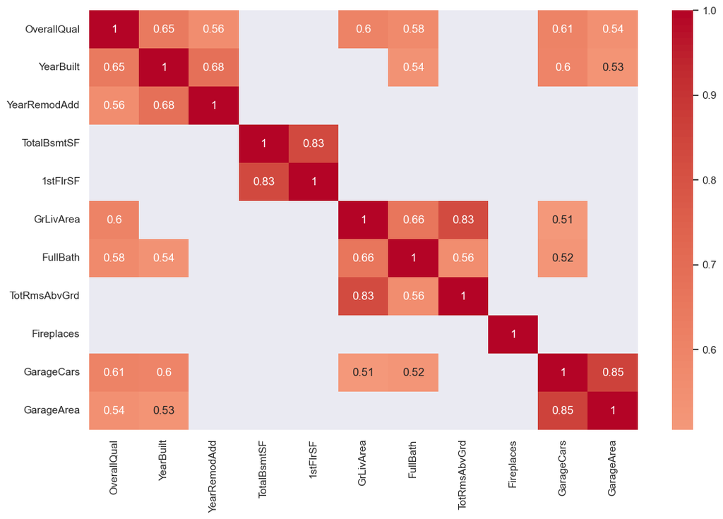

```python
sns.heatmap(
    data = df_entramiento_copia[correlaciones_fuertes.index].corr('spearman')[df_entramiento_copia[correlaciones_fuertes.index].corr('spearman') > 0.5],
    center = 0,
    cmap = 'coolwarm',
    annot = True
);
```

```python
correlaciones_fuertes.sort_values(ascending=False)
```

```
OverallQual     0.809829
GrLivArea       0.731310
GarageCars      0.690711
YearBuilt       0.652682
GarageArea      0.649379
FullBath        0.635957
TotalBsmtSF     0.602725
1stFlrSF        0.575408
YearRemodAdd    0.571159
TotRmsAbvGrd    0.532586
Fireplaces      0.519247
Name: SalePrice, dtype: float64
```

```python
df_entramiento_copia.drop(['YearRemodAdd','1stFlrSF','TotRmsAbvGrd','GarageArea'],axis = 1,inplace = True)
df_prueba_copia.drop(['YearRemodAdd','1stFlrSF','TotRmsAbvGrd','GarageArea'],axis = 1,inplace = True)
```

### Preprocesamiento de las variables

```python
from sklearn.preprocessing import OneHotEncoder, OrdinalEncoder

escalador = RobustScaler()
Codificador = OneHotEncoder()

# Definiendo la matriz predictora y el arreglo objetivo
X_train = df_entramiento_copia.drop(['SalePrice'],axis = 1)
y_train = df_entramiento_copia['SalePrice']
X_test = df_prueba_copia

# Eliminando diferencia de dimensiones
drops = []
for i,j in zip(X_train.select_dtypes('O').columns,X_test.select_dtypes('O').columns):
    if len(X_train[i].unique()) != len(X_test[j].unique()):
        drops.append(i)

X_train = X_train.drop(drops,axis = 1)
X_test = X_test.drop(drops,axis = 1)

# Codificando los datos
X_train_codificado = pd.get_dummies(X_train,drop_first=True)
X_test_codificado = pd.get_dummies(X_test,drop_first=True)

# Escalando los datos
X_train_codificado_escalado = escalador.fit_transform(X_train_codificado)
X_test_codificado_escalado = escalador.fit_transform(X_test_codificado)
y_train_escalado = escalador.fit_transform(y_train.values.reshape(-1,1))
```

```python
modelo = RandomForestRegressor()
```

```python
modelo.fit(X_train_codificado_escalado,y_train_escalado.ravel())
```

```
RandomForestRegressor()
```

```python
y_prediccion = modelo.predict(X_test_codificado_escalado)
```

```python
y_prediccion_revertido = escalador.inverse_transform(y_prediccion.reshape(-1,1))
```

```python
prediccion = pd.DataFrame()
prediccion['Id'] = datos_prueba['Id']
prediccion['SalePrice'] = np.round(y_prediccion_revertido)
```

```python
prediccion['SalePrice'] = prediccion['SalePrice'].astype('int64')
```

```python
modelo.score(X_train_codificado_escalado,y_train_escalado.ravel())
```

```
0.9794541114003772
```

```python
prediccion.to_csv('Predicciones.csv',index=False)
```